# Uncovering Consumer Insights via Text Mining: Sentiment Analysis & LDA Topic Modeling

Chi Nghia Nguyen

2026-03-26

# 1. Research Question

What are the underlying themes (topics) and emotional polarities (sentiments) driving customer satisfaction or dissatisfaction in e-commerce product reviews, and how can these unstructured insights be leveraged for product strategy?

# 2. Methodology

To extract insights from unstructured textual data, this study employs **Natural Language Processing (NLP)** techniques. First, a Lexicon-based **Sentiment Analysis** is applied to quantify the emotional polarity of consumer reviews. Second, **Latent Dirichlet Allocation (LDA)**, an unsupervised generative probabilistic model, is utilized for **Topic Modeling** to discover hidden semantic structures within the text.

Prior to modeling, rigorous data preprocessing is conducted, including tokenization, stop-word removal, and scaling, to ensure the validity of the text corpus.

### Data Import and Preprocessing

```r
# ---------------------------------------------------------
# CLEAN CODE: Step 1 - Data Import and Text Preprocessing
# ---------------------------------------------------------
# Load required libraries
library(dplyr)
library(tidytext)
library(ggplot2)
library(tidyr)
library(jsonlite)
library(wordcloud)
library(reshape2)

# 1. Read JSON data
reviews_data <- stream_in(file("/Users/nguyenchinghia/Downloads/Cell_Phones_and_Accessories_5 2.json"))
```

[output not shown]

```r
# To prevent memory overload, we sample 10,000 random reviews for this analysis
set.seed(123)
sample_reviews <- reviews_data %>% sample_n(10000)

# 2. Select the core columns (reviewText & overall) and add a unique ID
nlp_data <- sample_reviews %>%
  select(review_id = reviewerID, rating = overall, text = reviewText) %>%
  mutate(review_id = row_number()) %>% # Generate simple ID
  filter(!is.na(text))

# 3. Text Cleaning: Tokenization and Stop Words removal
tidy_reviews <- nlp_data %>%
  unnest_tokens(word, text) %>%
  anti_join(stop_words)

# Display the first 6 rows of clean words
head(tidy_reviews)
```

```
##   review_id rating    word
## 1         1      2    fits
## 2         1      2   color
## 3         1      2 buttons
## 4         1      2    hard
## 5         1      2    push
## 6         1      2   times
```

### Analytical Model 1: Sentiment Analysis & WordCloud

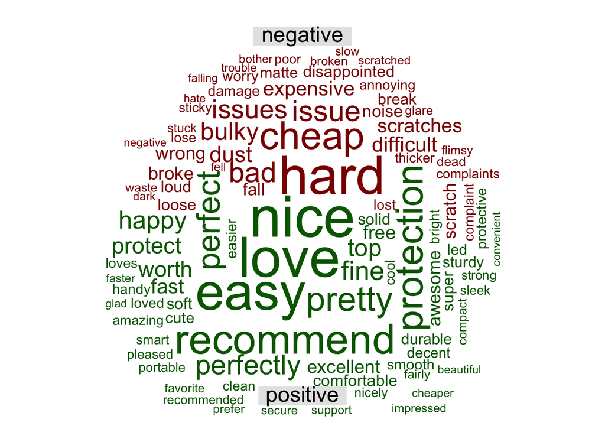

```r
# ---------------------------------------------------------
# CLEAN CODE: Step 2 - Lexicon-based Sentiment Analysis
# ---------------------------------------------------------

# Generate a Comparison Cloud to visualize positive vs negative terms
tidy_reviews %>%
  inner_join(get_sentiments("bing")) %>%
  count(word, sentiment, sort = TRUE) %>%
  acast(word ~ sentiment, value.var = "n", fill = 0) %>%
  comparison.cloud(colors = c("darkred", "darkgreen"),
                   max.words = 100,
                   title.size = 1.5)
```

### Analytical Model 2: LDA Topic Modeling

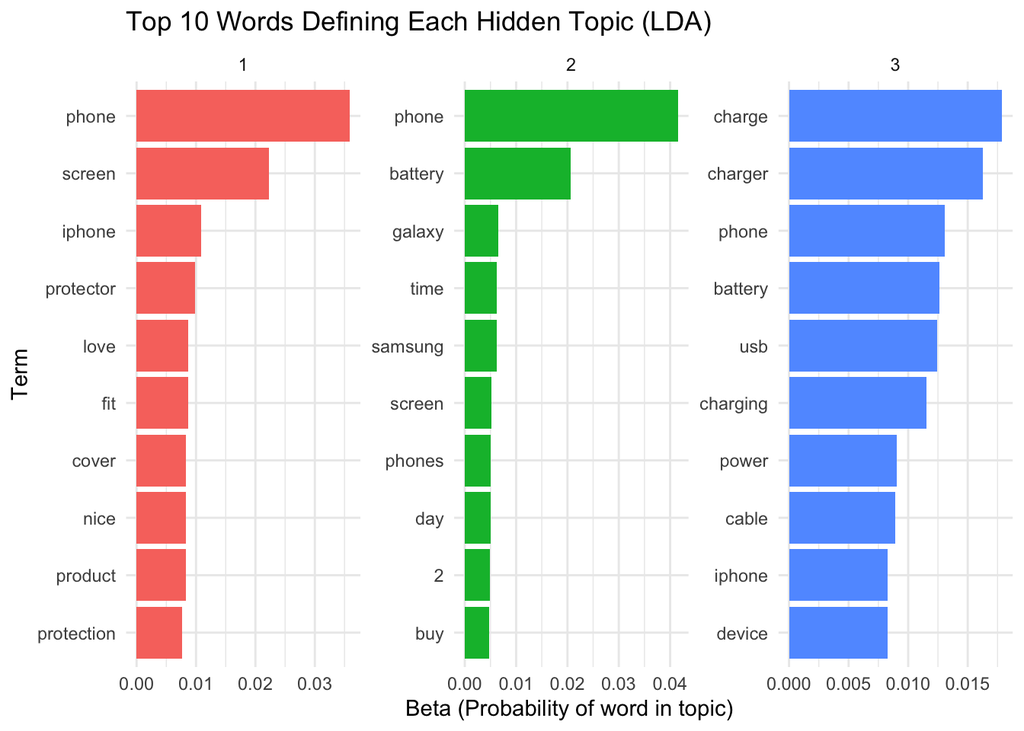

```r
# ---------------------------------------------------------
# CLEAN CODE: Step 3 - Latent Dirichlet Allocation (LDA)
# ---------------------------------------------------------
library(topicmodels)

# 1. Convert data to Document-Term Matrix (DTM) for LDA
reviews_dtm <- tidy_reviews %>%
  count(review_id, word) %>%
  cast_dtm(review_id, word, n)

# 2. Run LDA Algorithm to uncover 3 latent topics (k = 3)
lda_model <- LDA(reviews_dtm, k = 3, control = list(seed = 123))

# 3. Extract the core words defining each topic
review_topics <- tidy(lda_model, matrix = "beta")

# 4. Visualize the top 10 terms for each topic
top_terms <- review_topics %>%
  group_by(topic) %>%
  slice_max(beta, n = 10) %>%
  ungroup() %>%
  arrange(topic, -beta)

# Create a bar chart for Topic Modeling
top_terms %>%
  mutate(term = reorder_within(term, beta, topic)) %>%
  ggplot(aes(beta, term, fill = factor(topic))) +
  geom_col(show.legend = FALSE) +
  facet_wrap(~ topic, scales = "free") +
  scale_y_reordered() +
  theme_minimal() +
  labs(title = "Top 10 Words Defining Each Hidden Topic (LDA)",
       x = "Beta (Probability of word in topic)",
       y = "Term")
```

# 3. Findings & Implications

**1. Findings (Textual & Behavioral Insights):** The integration of Lexicon-based Sentiment Analysis and LDA Topic Modeling on unstructured consumer reviews explains various critical insights related to post-purchase behavior:

- **The Sentiment Asymmetry (Design vs. Durability):** The WordCloud reveals a stark contrast in sentiment drivers. Positive emotions are heavily associated with aesthetics and product designs (e.g., “beautiful”, “nice”, “easy”, “perfectly”). By contrast, negative sentiments are strictly tied to material durability and functionalities (e.g., “cheap”, “broke”, “flimsy”, “waste”, “disappointed”).
- **Latent Themes in Consumer Discourse:** The LDA algorithm successfully deconstructed the chaotic text corpus into three major actionable business topics:
  - *Topic 1 (Protective Accessories & Fitment):* Dominated by terms like “screen”, “protector”, “cover”, and “fit” that highlights phone accessories, the precision of physical dimensions (“fit”) is the ultimate driver of customer satisfaction.
  - *Topic 2 (Battery Longevity & Android Devices):* Characterized by “battery”, “galaxy”, “time”, “day”, and “samsung” which indicates a persistent anxiety regarding battery degradation and daily usage time among Android users.
  - *Topic 3 (Charging Infrastructure):* Characterized by “charge”, “cable”, “usb”, and “power” which reveals to a high failure rate or compatibility friction surrounding charging peripherals.

**2. Implications (Strategic & Academic Contributions):**